# Intro to Data Science Final Project

Author

Vivian Myers, Weina Lu, Caroline Cook

# Data Description

## Topic & Origin

**The main research** question the data can be used to address is: What factors correlate with dementia? This data[^1] was retrieved from [MRI and Alzheimers Kaggle](https://www.kaggle.com/datasets/jboysen/mri-and-alzheimers?resource=download). The original data set was from [OASIS](https://sites.wustl.edu/oasisbrains/), and data was collected through laboratory visits. OASIS’s goal was to make neuroimaging data sets more accessible and promote scientific discovery.

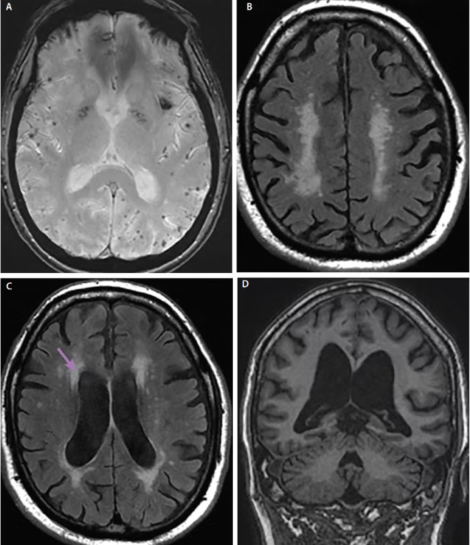

Four MRI scan of progressing Alzheimer’s disease.

## Description of Variables

The `dplyr::glimpse()` function can be used to get a quick overview of a data set’s contents.

```
Rows: 235
Columns: 6
$ age   <dbl> 74, 55, 73, 74, 52, 81, 76, 82, 39, 89, 48, 80, 69, 82, 58, 86, …
$ m_f   <chr> "F", "F", "F", "M", "F", "F", "M", "M", "M", "F", "F", "F", "F",…
$ educ  <dbl> 2, 4, 4, 5, 3, 5, 2, 2, 3, 5, 5, 3, 2, 2, 5, 2, 2, 1, 4, 4, 5, 3…
$ cdr   <dbl> 0.0, 0.0, 0.5, 0.0, 0.0, 0.0, 0.5, 0.5, 0.0, 0.0, 0.0, 0.5, 0.5,…
$ e_tiv <dbl> 1344, 1147, 1454, 1636, 1321, 1664, 1738, 1477, 1636, 1536, 1326…
$ n_wbv <dbl> 0.743, 0.810, 0.708, 0.689, 0.827, 0.679, 0.719, 0.739, 0.813, 0…
```

One row in the data set is one participant. For example, the first row is a 74 year old female participant who graduated high school. She has no signs of dementia. Her brain has a volume of 1344 mL, which is 74.3% of the expected total brain volume accounting for her head size.

- age: Age in years.
- m_f: Gender, unclear how they define/determined gender here (self-identification, sex at birth, etc).
- educ: Education level. 1: did not graduate high school, 2: graduated high school, 3: did not graduate college, 4: graduated college, 5: beyond college.[^2]
- cdr: Clinical Dementia Rating. 0: non-demented, 0.5: very mild dementia, 1: mild dementia, 2: moderate dementia. Participants with CDR above 0 were diagnosed with probable Alzheimer’s.[^3]
- e_tiv: Estimated total intracranial volume, which is the volume of the cranial cavity in mL.
- n_wbv: Normalized whole brain volume, which is the brain volume relative to total intracranial volume.

# Phase 3: Summarization

Table 1: Intracranial and Normalized Whole Brain Volumes by Gender

| Gender | Average Intracranial Volume(mL) | Average Normalized Whole Brain Volume |
| --- | --- | --- |
| F | 1396.31 | 0.75 |
| M | 1584.28 | 0.74 |

From Table 1, we observe that males, on average, have larger intracranial columes—i.e., larger skulls—while females have a slightly higher average normalized whole brain volume (NWBV), meaning a greater proportion of their cranial space is occupied by brain tissue.

These observations suggest that a larger intracranial volume does not correspond to a larger normalized whole brain Volume; therefore, men’s larger average intracranial volume does not imply that they have larger brains.

Table 2: Clinical Dementia Rating by Education Level

| Education Level | Average Clinical Dementia Rating |
| --- | --- |
| 1 | 0.522 |
| 2 | 0.359 |
| 3 | 0.245 |
| 4 | 0.240 |
| 5 | 0.167 |

As shown in Table 2, average Clinical Dementia Rating (CDR) scores decrease with increasing levels of education, indicating a negative correlation between educational attainment and dementia severity. This trend suggests that higher education may be associated with a reduced risk of dementia.

Table 3: Clinical Dementia Rating by Age Range

| Age Range | Average Clinical Dementia Rating |
| --- | --- |
| <60 | 0.000 |
| 60-69 | 0.225 |
| 70-79 | 0.398 |
| 80-89 | 0.355 |
| 90+ | 0.231 |

As shown in Table 3, average CDR scores increase with age, peaking in the 70–79 age group. Interestingly, scores decline slightly in the 80–89 and 90+ groups, which may reflect survivorship effects or sampling bias. This trend supports the association between aging and dementia severity, while also suggesting more complex trajectories among the oldest age groups.

# Phase 4: Data Visualization

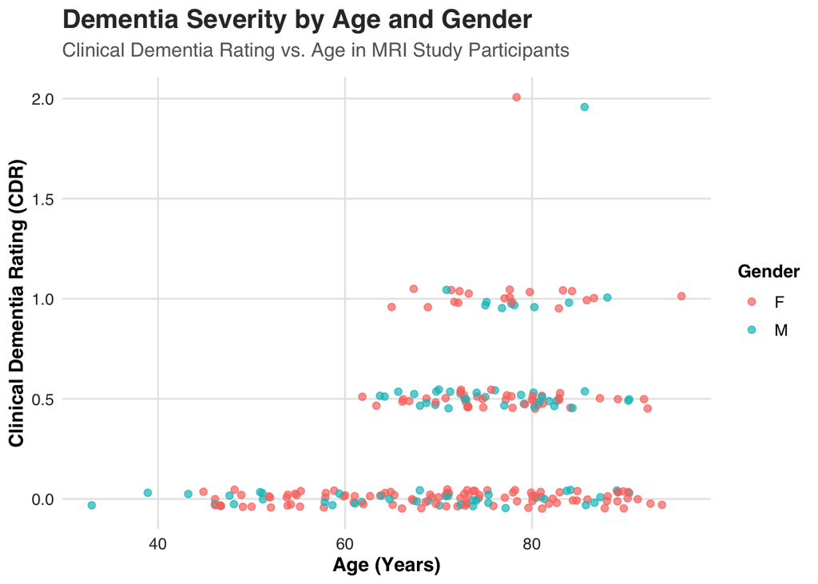

Figure 1: Clinical Dementia Rating vs Age Colored by Gender

In Figure 1, CDR was plotted against age and colored by gender. The plot indicates that as age increases, so does CDR, indicating an increased risk of dementia with age. Gender does not appear to have a clear trend.

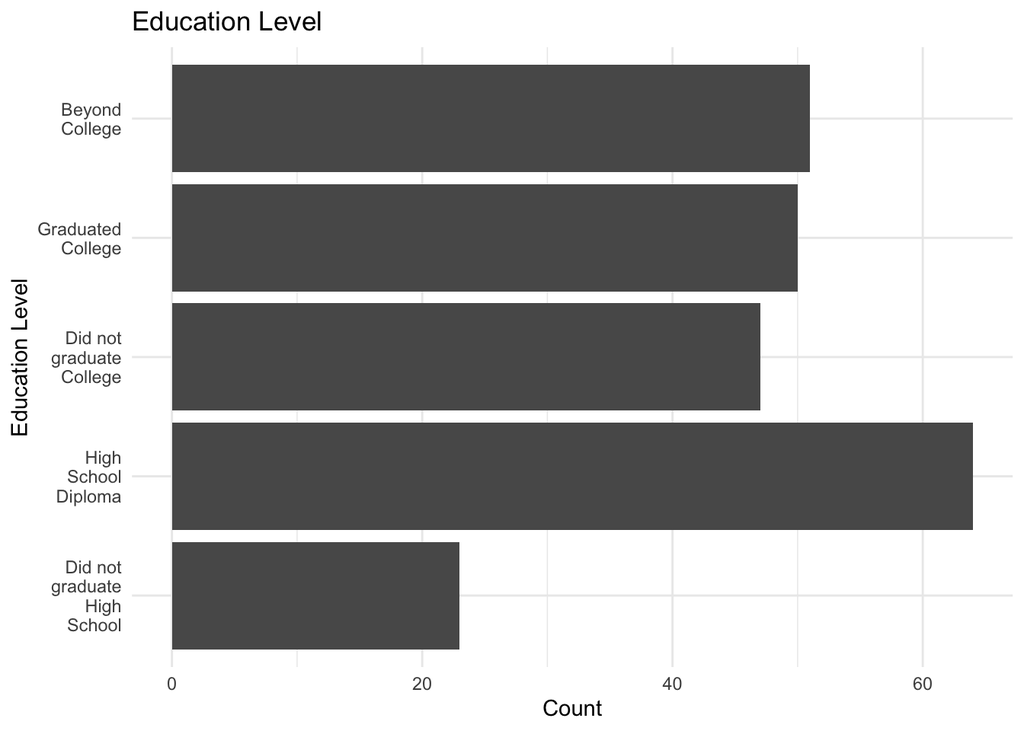

Figure 2: Education Levels

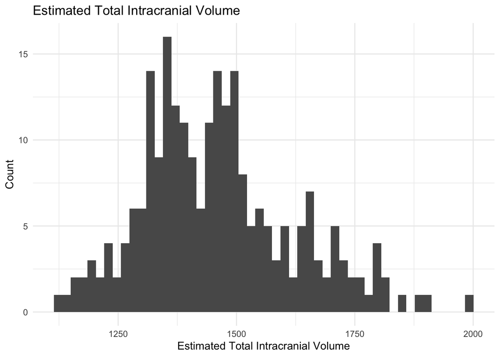

Figure 3: Estimated Total Intracranial Volume

In Figure 3, estimated total intracranial volume (ETIV) was plotted on the x-axis. The histogram indicates that most participants have an ETIV between 1300 and 1600. There is one outlier at 2000 ETIV.

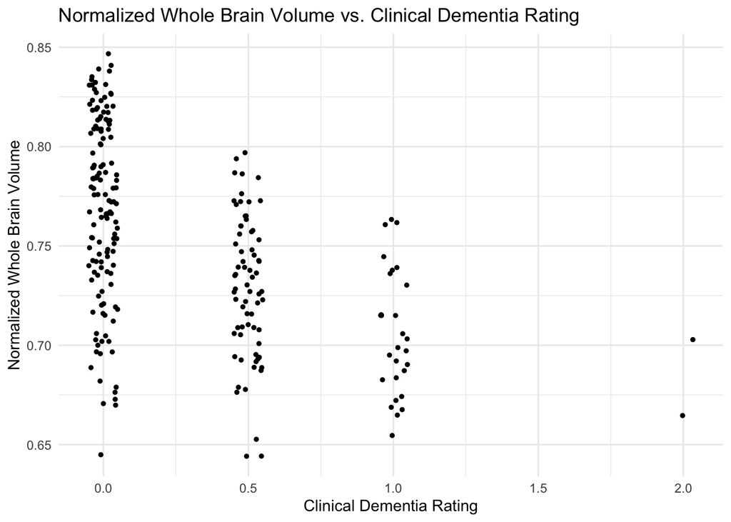

Figure 4: Normalized Whole Brain Volume vs. Clinical Dementia Rating

In Figure 4, NWBV was plotted on the y-axis, and CDR was plotted on the x-axis. The plot shows that, on average, people with a 0 CDR have a higher NWBV. It also shows that as CDR increases, NWBV tends to decrease. This indicates a potential inverse relationship between CDR and NWBV.

# Phase 5: Ethics & Impact

This data was originally collected through laboratory visits by Washington University in St. Louis Medicine’s Open Access Series of Imaging Studies (OASIS) project. OASIS’s goal is to make neuroimaging data more accessible to the scientific community and to promote clinical neuroscience discovery.

People can use this data to discover new potential factors that could influence the risk of of Alzheimer’s. For example, Saleem et al. (2022) uses OASIS data sets to improve Alzheimer’s diagnosis. This data can also be used to study other factors unrelated to Alzheimer’s, such as the relationship between education level and gender.

Some potential harms that could come from using this data is determining causation between factors when there is just correlation, which could hinder scientific discovery and lead to misdiagnoses. In addition, studies that use sex/gender as a variable always carry the risk of data being used to support misogynistic perspectives, such as if the data reveals that men have a higher average education level. This data may also not be racially diverse, but we don’t know because they did not track that data.

This data set aims to examine factors that could influence the risk of or be used to diagnose Alzheimer’s. As a result, there can be a lot of correlation found between the variables.

## References

Saleem, Tausifa Jan, Syed Rameem Zahra, Fan Wu, Ahmed Alwakeel, Mohammed Alwakeel, Fathe Jeribi, and Mohammad Hijji. 2022. “Deep Learning-Based Diagnosis of Alzheimer’s Disease.” *Journal of Personalized Medicine* 12 (5): 815. https://doi.org/10.3390/jpm12050815.

## Footnotes

[^1]: Cross sectional data collected in 2007.
[^2]: Scale according to [OASIS Fact Sheet](https://bpb-us-w2.wpmucdn.com/sites.wustl.edu/dist/6/4383/files/2024/03/oasis_cross-sectional_facts-bcc7a002dfb104f4.pdf)
[^3]: Scale according to [OASIS Fact Sheet](https://bpb-us-w2.wpmucdn.com/sites.wustl.edu/dist/6/4383/files/2024/03/oasis_cross-sectional_facts-bcc7a002dfb104f4.pdf)